# Amazonian Narratives in Presidential Discourse (1985 to 2020)

Henrique Sposito[^1]

Livio Silva-Muller[^2]

11th of November of 2021

# 1 Introduction

> “The world should understand that the Brazilian Amazon has an owner: the Brazilian people.” (Lula, May 2008)[^3]

> “Do you know what ‘Triple A’ is? It is the Amazon, Andes and Atlantic. These represent 136 million hectares, and the first world wants to administer these areas.” (Bolsonaro, July 2019)[^4]

Preserving the Amazon has rarely been the top priority of Brazilian federal governments. Though deforestation rates began to steadily increase in 2012 (see Carvalho et al. 2019), after a decade of decline, they spiked in 2019 after Bolsonaro took power (INPE 2021). This is no surprise as the current federal government is weakening the foundations of the Brazilian environmental governance system through budgetary cuts, presidential appointments, and dissociating government from civil society (see Ferrante and Fearnside 2019). These factors contributed to record-high fires in the Amazon and unprecedented monthly rates of deforestation during the dry seasons of 2019, 2020, and 2021 (INPE 2021). Although policy discontinuities between Bolsonaro’s Amazon agenda and previous governments have been documented by academic scholarship and specialized media (see Abessa, Famá, and Buruaem 2019; Spring 2021), we lack empirical accounts of how Amazonian discourses changed. Pokorny et. al (2021, p. 2208), for example, argue that Bolsonaro’s Amazonian discourses shifted drastically in relation to earlier governments, giving rise to a “populist neoliberal” phase of discourse and policy developments in the region. However, the authors rely on a few disconnect quotes from Bolsonaro about the Amazon to exemplify phases defined by policy discontinuities. How, then, have Amazonian presidential discourses changed in time?

Amazonian related political discourses at the top can help expand, or restrict, what types of behavior are expected and accepted in society in respect to the region. This is especially pertinent for deforestation as previous research found that expectations about government response, generated from material and discursive changes, are a crucial factor in decisions to deforest at the local level (Campbell 2015). When, for example, Bolsonaro says he will end the “industry of fines” in reference to institutions that police environmental crimes, the loud and clear message is that oversight will decrease (see Ferrante and Fearnside 2019). To study change and continuity in presidential discourses about the Amazon we build upon the environmental historiography literature which have documented cultural imaginaries of, and from, the region thoroughly, mobilized by presidents in discourse via political narratives.In so doing, we understand Amazonian narratives[^5] as originating in specific historical periods, connecting the discourse to the broader social history of the region and country.

We propose four ideal type Amazon related narratives in political discourses: sovereignty, developmentalism, conservationism, and anti-environmentalism. Sovereignty narratives touch on imaginaries of threat that hail from the time of the scramble for the Amazon (see Hecht and Cockburn 1990) to contextualize or justify proposed political actions of control, occupation, and monitoring of the region. Developmentalist narratives employ imaginaries of underdevelopment and economic needs in the region, advancing political actions related to exploring economically of the region and the forest (see Acker 2013). Conservatism narratives deploy imaginaries related to the value of the standing Amazonian ecosystem to justify political actions related to preserving the forest and idigenous peoples’ rights (see Hochstetler and Keck 2007). Anti-environmentalism builds upon imaginaries related to issues with socio-environmentalism and excess preservation for even development to justify political actions related to deregulation.

To analyze Amazonian narratives across time and space, we use a dataset of presidential discourse ranging from 1985 to 2020 with 6088 speeches and a combination of natural language processing and qualitative coding. We subset the text dataset to select texts which contain words related to Amazon. We, then, build a dictionary of terms to operationalize Amazonian narratives and trace their evolution and change across presidential mandates and stages (local, national, or international). By tying Amazonian narratives in presidential discourse to environmental historiography, we provide the first historically and empirically informed account of how, when, and where Amazonian narratives are mobilized at the top.

This paper proceeds as follows: we start with a brief review of the social sciences literature on the Brazilian Amazon. We then move to our conceptual framework, which ties environmental historiography to our understanding of narratives. We provide a targeted overview of recent Amazonian historiography, which serves the purpose of identifying and grounding ideal-typical narratives. Third, we discuss the data, methods, and the operationalization of these narratives. We then present our preliminary results by contextualizing them into the last decades of environmental governance in Brazil. We conclude by providing avenues for future research connecting political discourses and environmental related outcomes.

# 2 Grounding Amazonian narratives in the literature

## 2.1 The Brazilian Amazon in social sciences: where is culture and discourse?

We contend that presidential discourse at the top matters because it expands or restricts the range of possibilities for other actors. When presidents speak about the Amazon, it makes international headlines (Brice and Smith 2021; Harris 2021; Miranda 2021), inciting international responses, and feeds into the behavior of domestic actors, from investors to agricultural giants to local farmers, who take what presidents say into consideration. When presidents mobilize Amazonian narratives that connect the region to specific imaginaries of the future and past, they are touching upon shared webs of meaning about the region. So, before dissecting Amazonian narratives, we will dwell into the arena of Amazonian related culture. But how to situate political discourse and culture in social sciences literature about the Brazilian Amazon? In the following, we provide a synthetic review of the literature to argue that while ethnographers have been particularly successful exploring the role of culture in the Brazilian Amazon, we lack accounts that situate it at the level of discourse generally.

A substantial number of studies about the Amazon try to identify causes of and remedies to deforestation. This literature is interdisciplinary, ranging from ecology, to economics, to political sciences. It assesses the effectiveness of policies their relative contribution, or how they affect decision making of actors from rather rational perspectives at various levels (Arima et al. 2014; Assunção, Gandour, and Rocha 2015; Boucher, Roquemore, and Fitzhugh 2013; Nepstad et al. 2009). As it is particularly hard to econometrically tie discourse to deforestation outcomes, there are no studies that look at the effects of political discourses on deforestation systematically. There has been a recent call, though, to better account for the role of culture in the development of land systems’ use alongside demographic, economic, technological, and governance factors (de Waroux et al., 2021). Bringing culture in might help formalize findings from single case studies, hailing from ethnographies, that explain decisions to deforest, or not, based on individual and collective values rather than utility. de Waroux et al. (2021) propose to approach culture as a shared symbolic system or ‘webs of meaning’ that play a role in cognition and other structural drivers of land-use behavior.

Another line of inquiry is interested in explaining who influences Brazilian environmental policy and how. Researchers in this line of inquiry seek to understand interest formation, resembling international political economy approaches. This line of research has identified the role transnational connections (Keck and Sikkink, 1998; Hochstetler and Keck, 2007; Silva-Muller & Faul, 2021), domestic actors’ interests (Franchini and Viola, 2019), and bureaucrats (Abers 2019; Silva-Muller, forthcoming). Some authors attempt to bring cultural dimensions to these studies through ethnographic work. Rajão and Vurdubakis (2013), for example, conduct longitudinal participant observation with the environmental police (IBAMA) to argue that the process of rendering deforestation a stable object of knowledge, that can be objectively identified and sanctioned, is deeply social and full of antagonisms. Lahsen (2004; 2009) discusses how Brazil could become a net receiver of international funds for climate mitigation, though Brazilian policymakers often ignore the scientific evidence and push against such funding because of a national political culture of sovereignty protection inherited from the military dictatorship. Campbell (2015) proposes the concept of speculative accumulation to capture the practices of land-grabbers in the deforestation arch who make property appear and disappear based on their expectations of the future and attempts to rewrite the past through material practices (e.g. grillagem).

Nevertheless, there are very few studies looking into political discourses to explain who influence environmental police outcomes. Barros (2020), for instance, analyzes Amazonian discourse in the Brazilian Congress with the objective of identifying the main arguments put forth by congressmen. The main finding is that in congress the economic value of the Amazon for the cattle industry is the most salient narrative, leading the author to conclude there is a mismatch between the international debate (which focuses on preservation) and the national debate (which focuses on economic development). However, political discourses in the congress are less visible to the broader population than other types of political discourses at the top, such as presidential discourses. At the same time, congressional discourses have specific purposes of discussing, or proposing, legislation in a technical manner.

Except for ethnographers, who advanced multiple versions of why and how culture matters for deforestation in the Amazon and environmental policy outcomes in Brazil, we lack accounts of the importance of culture more generally. This is key as the expectations about the future regarding government’s response are a key variable in the decision to deforest or not (Campbell, 2015). Such expectations are informed by shared meanings and values (de Waroux et. al., 2021), which travel through various means including discourse at the top. Building on these studies and on cultural sociology, we propose to situate culture at the level of discursive practices and understand what narratives are mobilized, when and where.

## 2.2 Performing Amazonian narratives: environmental historigraphy and ideal types

Amazonian narratives constitute discourses that connect the region to specific imaginaries of the future and past. We argue that they touch on shared meanings about the Amazon that are available to the speaker as part of the larger social history of the region and country. To identify a few possible narratives, we utilize environmental historiography about the Amazon. We build Amazonian narratives as ideal types, that is, unified analytical constructs portraying a ‘pure’ version of a phenomenon (Weber 1949). In that sense, they rarely exist in its purest form. It serves the purpose of allocating empirical observations within a range of possibilities. The ideal types also help us deal with statements that perform different narratives. We broadly understand political discourses as performances seeking to appeal to diverse audiences across multiple political stages to project a definition of the situation (Goffman 1956, p. 3). As political stages, audiences, and time change, so do narratives. As with broader political discourses, narratives can appear together, not necessarily in consistent ways in time or across stages. As we show in section 3, our methodological strategy utilizing allows us to allocate statements within one or more ideal types, providing a more sophisticated portrayal of political discourse.

When speaking, depending on the stage, presidents have varying levels of scripted discourse. In a message to congress, for example, discourse might be carefully crafted by a handful of specialists. However, in inaugural speeches for a bridge in a small town in Brazil presidents might have more room to deliver a speech more freely. In the first case, alluding to specific Amazonian narratives might be a conscious decision. In the second case, an allusion might be more spontaneous as narratives are available as part of the larger repertoire. We adopt the idea of performing Amazonian narratives to capture this variety. In opposition to rational choice models that see speech as a function of calculated decision, performances involve both improvisation and preparation, which in turn are constrained by the set of available possibilities. We see performance as a less strict way of approaching the issue at hand. So, what Amazonian narratives can presidents perform?

*Sovereignty*

In The Fate of the Forest: Developers, Destroyers, and Defenders of the Amazon, a social history of the Brazilian Amazon dating 1990, Susanna Hecht and Alexander Cockburn write that all over the world tropical forests are destroyed, but “what imbues the case of the Amazon with such passion is the symbolic content of the dreams it ignites” (1991, p.1). It started with the first natural history of the New World, by Oviedo in 1535, who while naming mysterious plants and creatures, recounts the stories of conquest of local populations and gold hoarders (ibid). The dream of fortunes to be found in the Eldorado composed the imaginaries of bandeirantes from the southeast of Brazil and colonizers from everywhere else. It rendered the territory the venue for aspiration and object of an intense scramble in the subsequent centuries, defined as “a […] form of nation building […]” (Hecht and Cockburn 1991, preface). The Portuguese empire and subsequently the Brazilian monarchy were concerned with establishing their territory. In the process of securing Amazonian borders, Brazil thwarted “the imperial ambitions of France, Britain, the United States, Belgium, Bolivia, and Peru (Hecht, 2013, p. 8), and when the dust settled and the scramble was over, half of the Amazon emerged Brazilian. While Brazilian military diplomacy was very successful, the process did not come without its traumas. A significant experience were the negotiations with Bolivia in 1902 to secure the Amazonian state of Acre, during which they found out about American attempts to trick Brazil (Hecht and Cockburn, 1991). This case was still part of the memory of the generals who led the country during the military dictatorship of 1964 and wanted to protect Brazil’s sovereignty over the Amazon from the communist threat.

We understand claims of sovereignty as a particular narrative that touches on imaginaries of threat that hail from the time of the scramble for the Amazon. The sovereignty narrative advances the view that the Brazilian Amazon is Brazilian and foreign presence in the region needs to be monitored closely.

*Developmentalism*

The dictatorships of Vargas (1937-46) and the military (1964-89) took over the task of modernizing the Amazon. This was mostly done in a particularly “high-modernist” (Scott, 1998) with military bureaucrats designing centralized policies aiming at conquering nature and developing the region. In 1966, for example, the Brazilian Military government launched Operation Amazon, a policy to modernize the region based on a set of assumptions (Acker 2013). First, nature should be conquered by men. Second, exploiting natural resources would render the Amazon region a global powerhouse. Third, such a project would integrate the region with the rest of the country. Concretely, this meant a series of infrastructure projects, such as roads and dams, incentives for settlers to develop ranches and expand the agricultural frontier, as well as establishing tax free zones to attract industry. The capital to conduct such changes, paradoxically, came from national and international sources (Acker 2013), leading to a series of national and international enterprises settling in the Amazon region.

The developmentalist narrative advances the view that the Brazilian Amazon needs to be developed and modernized. This includes expanding the agricultural frontier through incentives, creating infrastructure as roads and dams, and fostering industries through tax-free zones. It has its origins in the policies of the 1930s that attempted to modernize the recently consolidated region (Hecht and Cockburn, 1990), but were extended throughout the 20th century. It also captures arguments of the 20th century that defended the integration of indigenous populations into the nation via assimilation and inclusion in economic life. This narrative employs imaginaries of underdevelopment and economic needs in the Amazon while, at the same time, focus on the unexplored economic potential of the region and forest.

*Conservationism*

The rapid economic changes in the region in the 1960s, 70s, and 80s were matched with the birth of environmental institutions such as the New Forest Code (1964), the Secretary of Environment (1973), and the National Environment Law (1980) (Drummond and Barros-Platiau 2006). This is mostly because “the generals had unleashed forces beyond their control, and now the Amazon faced its apocalypse” (Hecht and Cockburn, 1990, p. 141). As deforestation, fires, and violence rose in the region and caught international attention, the military government deemed as necessary the establishment of an environmental bureaucracy. Concurrently, a new form of environmentalism in civil society consolidated in the 1990s: socio-environmentalism. Hochstetler and Keck define it as an emphasis on local livelihoods of people while protecting nature, which has its roots in the wider process of democratization of Brazil, the local advocacy and assassination of Chico Mendes, and the multi-level preparation for the 1992 Earth Summit in Rio de Janeiro (2007). The latter made many international NGOs establish their offices and presence in Brazil (e.g. WWF, GreenPeace, Friends of the Earth, Conservation International). International foundations started to increase their operations in the country and channel funds to NGOs and governmental institutions working in the Brazilian Amazon. The development of this new governance ecosystem led to increased professionalization of local NGOs which, in turn, resulted in a more systematic participation of civil society in public policy surrounding the Brazilian Amazon (Hochstetler and Keck 2007).

The conservationist narrative advances the view that Amazon should be preserved, deforestation should be halted, and the sustainable practices of indigenous and local peoples should be maintained through protection of their territories and rights to self-determination (see Hochstetler and Keck 2007). This narrative focuses on imaginaries related to the values of a standing forest and of preserving the ecosystem of natures and peoples in the region.

*Anti socio-environmentalism*

In the early 2000s, many of the ideas developed by socio-environmentalism became public policy, leading to a sharp decrease in deforestation in the Amazon from 2004 to 2012 (Arima et al. 2014; Assunção, Gandour, and Rocha 2015; Boucher, Roquemore, and Fitzhugh 2013; Nepstad et al. 2009). Brazil boasted of an image of strong deliverer, with not only the allegedly best legislation in place but also concrete implementation results (Franchini & Viola, 2019). As deforestation rates started to increase in 2012, and more rapidly during Bolsonaro’s administration in 2019, socio-environmentalism fell under attack. Previous governments and NGOs were accused of preserving too much and having veiled financial and political interests.

The anti socio-environmentalist narrative advances views that socio-environmentalism is a problem. It highlights the economic benefits related to exploration, while emphasizing as well as the costs of preservation. It differs from the developmentalist narrative, as it attacks NGOs and local populations for the excesses of preservation. These attacks diverge in nature, from claiming NGOs have vested international interests to stating they fake numbers or set fire to the forest.

# 3 Operationalizing Amazonian narratives: data and methods

We start with a dataset of official presidential speeches since 1985 containing 6088 speeches. This body of speeches was scrapped from the official library of the Brazilian executive branch, and it includes a range of speeches from the UN general assembly to national congress, to business associations, to small events. The beginning date, 1985, reflects the date when democracy came back to Brazil, indirectly at first at the national level. With democracy back, political discourses are assumed to reflect a broad range of interests from voters to international pressure. We extract the location and date of each speech and code for stage (Amazonian states, non-Amazonian states, other, or international) to see if frequencies of narratives change depending on the audience and time. We then clean the text by removing some punctuation, accents, and making all the text lower case.

The broad dataset is then subset to contain only speeches that mention the word Amazon, or words that stem from the words (i.e. Amazonian). We assume that these speeches are, at least partially, about the Amazonon, the rain forest, and politics in the region. We find that 861 presidential speeches mention the word Amazon at least once. Subsequently we extract the sentences before and after the word Amazon is mentioned. This creates a contextualized statement that we consider an observation of an Amazonian narrative. It is at this level that we conduct our analysis in three steps. First, we start by providing some general descriptive statistics on the word Amazon in presidential discourse. Second, we then conduct a structural topic model (unsupervised machine learning) to inductively identify the most frequent combinations of words that appear in all Amazonian narratives. Here, words clustered are assumed to be a topic. Third, we deductively operationalize the four ideal-typical Amazonian narratives in dictionaries and provide its appearance and variation across time.

# 4 Exploratory analysis

In the following, we will show our work in progress in terms of the empirical analysis. At the moment, we are trying to figure out what methods we will actually use and why. The number of speeches mentioning the Amazon (n=861), is not high enough to justify certain machine learning approaches as manually coding a fraction. We tested more inductive approaches (topic modelling), and it seems to work well, but at the same time the text volume is too small to justify. As there are other factors we are interested add ( e.g. a measure of intensity, how (a)permissive and (b)explicit is the discourse), we think a combination of manual coding and more quantitative approach might help.

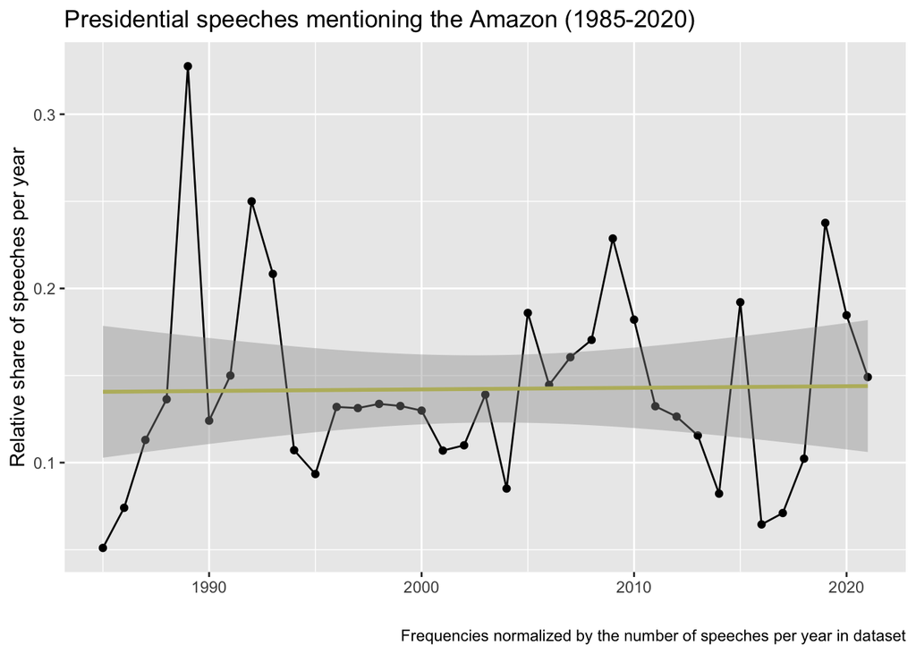

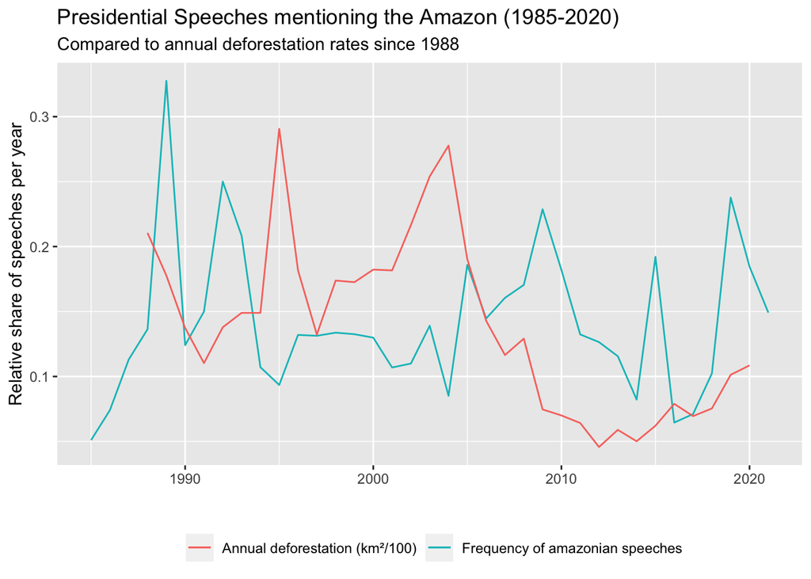

From the first plot, the proportion of speeches that mention the word “Amazon” increase in frequency in 1989 (possibly related to Amazon Fires coverage from the New York Times see [here](https://www.nytimes.com/1988/08/12/world/vast-amazon-fires-man-made-linked-to-global-warming.html) and [here](https://www.nytimes.com/1989/03/23/world/brazil-smarting-from-the-outcry-over-the-amazon-charges-foreign-plot.html)), around 1992 (likely related to the Rio Conference), from 2005 to 2010 (possibly related to the “preservation” legislation turn under the Lula Administration), and after 2016 (possibly related to increasing deforestation rates and international attention). An interesting finding here is that while there is fluctuations along time, mentions to the Amazon did not increase or decrease, maintaining a general average of around 15% appearance in speeches. A second interesting finding is that mentions to the Amazon in presidential discourse do not correlate with deforestation rates. This might be due to different reasons: first, deforestation rate data is published once a year, so international response and presidential discourse are lagged. Relatedly, wider access to this data only started in the 2000s.A more interesting measure to use would be fire data or DETER data, which comes out monthly and might drive discourse. Second, deforestation data might correlate better with specific Amazonian narratives rather than mentions in general. We will test this idea in future versions.

| Stage | Amazon_speeches | All_speeches |
| --- | --- | --- |
| Amazonian_States | 16.26 % | 9.74 % |
| International | 18.82 % | 21.45 % |
| Non_Amazonian_States | 53.19 % | 58.77 % |
| Non_Identified | 11.73 % | 10.04 % |

The summary table illustrates that more speeches that mention the Amazon proportionally take place in Amazonian states in comparison to their proportion in all speeches. However, when it comes to international settings, a lower proportion of the speeches that mention the Amazon take place in international settings in comparison to all speeches. We find this counter-intuitive, as many scholars tend to associate Brazil’s prominent role in international environmental governance. At the moment, we still can not say for sure that this finding is robust. We operationalize international stage as anything that is not Brazil, so it includes speeches in African countries for instance. We will work towards a better measure that separates international stage from other countries and re-run this to see if it still holds.

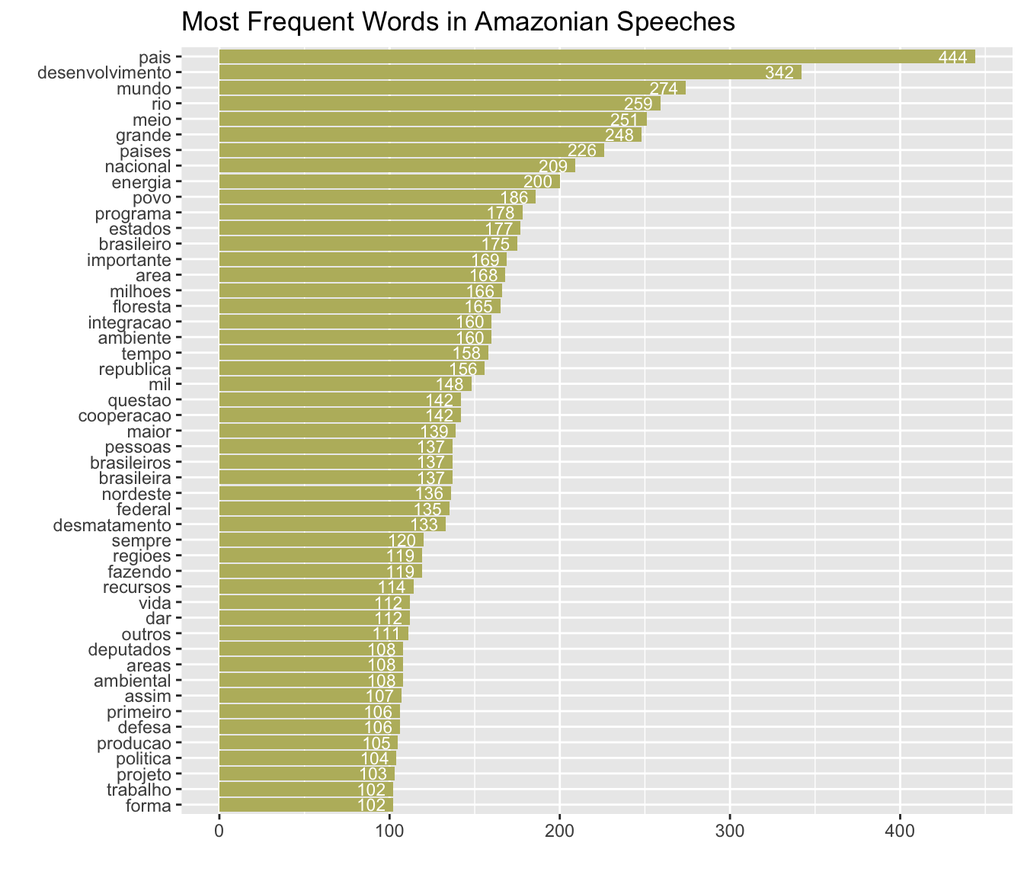

| bigram | n |
| --- | --- |
| meio ambiente | 152 |
| forcas armadas | 71 |
| zona franca | 71 |
| visite site | 66 |
| palavra it | 54 |
| site secretaria | 53 |
| desenvolvimento sustentavel | 51 |
| lula silva | 48 |
| inacio lula | 47 |
| milhoes hectares | 47 |

[output cut: 9990 more lines]

In terms of most frequent words, we already observe mentions related to the narratives we expect (develop, integrate, produce, deforestation). Pairs of words (bigrams) also point towards the same (meio ambiente, forcas armadas, zona franca, desenvolvimento sustentavel).

Top 30 Words Per President

| Sarney | Collor | Itamar | FHC | Lula | Dilma | Temer | Bolsonaro |
| --- | --- | --- | --- | --- | --- | --- | --- |
| grande | meio | iniciativa | rio | pais | pais | seguranca | mundo |
| pais | milhoes | integracao | energia | desenvolvimento | conferencia | forcas | paises |
| desenvolvimento | ambiente | paises | it | mundo | mulheres | estados | grande |
| area | floresta | cooperacao | desenvolvimento | milhoes | desmatamento | armadas | desenvolvimento |
| cooperacao | defesa | mercosul | integracao | republica | cumprimento | desmatamento | pais |
| paises | recursos | tratado | cardoso | desmatamento | mundo | meio | estados |
| nacional | brasileiros | grupo | meio | brasileiro | presentes | pais | meio |
| meio | problema | america | pais | pessoas | programa | publica | outros |
| rio | programa | desenvolvimento | tempo | mil | desenvolvimento | tempo | prezado |
| ambiente | ambiental | economico | palavra | nacional | deputados | brasileiro | alguns |
| programa | brasileiro | amazonico | fazendo | rio | federal | exemplo | decreto |
| povo | desenvolvimento | amazonicos | grande | secretaria | nordeste | interessante | floresta |
| atraves | exemplo | comercio | venezuela | silva | maior | nordeste | forma |
| natureza | questao | futuro | povo | paises | paises | presenca | momento |
| mundo | trabalho | parlamento | nacional | estados | regioes | banco | realmente |
| oportunidade | estados | andino | madeira | meio | estados | inteligencia | sustentavel |
| sarney | hectares | assembleia | realmente | voce | grande | momento | terra |
| ambiental | lado | grande | itacoatiara | importante | meio | ambiente | ambiental |
| brasileiro | mundo | livre | importante | programa | nacional | area | indigenas |
| brasileiros | preservacao | politica | presenca | site | cidades | banda | militar |
| futuro | republica | protecao | feito | visite | interior | disse | povo |
| projeto | somente | abertura | producao | brasileira | milhoes | larga | queremos |
| maior | acailandia | area | assim | povo | questao | questao | soberania |
| patrimonio | dessa | brasileiros | maneira | grande | sempre | rondonia | ambiente |
| politica | evitar | chile | questao | energia | senador | espirito | biodiversidade |
| mil | jornalista | colombia | sempre | nordeste | estar | extraordinaria | importante |
| grandes | pais | conjunto | regioes | 1 | importante | federais | questao |
| tratado | planeta | democracia | tao | coisas | banco | federal | fogo |
| cidade | tabatinga | economica | populacoes | floresta | des | floresta | maior |
| fronteiras | 400 | guiana | porto | deputados | en | integracao | pessoas |

Moving to most mentioned words by presidents, there are some interesting anectodal findings. For instance, deforestation appears to be more salient in the vocabulary employed by Lula, Dilma and Temer versus their counterparts. The words “soberania” and “military” only appears as part of Bolsonaro’s vocabulary.Desenvolvimento, on the other hand, seems to be part of all presidents vocabulary except of Temer.

Top 10 Words per Topic for Presidential Speeches Mentioning the Amazon

| Topic | Terms |
| --- | --- |
| 1 | pais, desenvolvimento, nordeste, mil, programa, importante, mundo, meio, recursos, exemplo |
| 2 | pais, mundo, desmatamento, floresta, milhoes, pessoas, conferencia, paises, questao, brasileira |
| 3 | pais, povo, grande, energia, gas, mundo, petroleo, urucu, petrobras, desenvolvimento |
| 4 | cooperacao, paises, integracao, tratado, desenvolvimento, america, area, mercosul, amazonicos, mundo |
| 5 | deputados, silva, presentes, republica, pais, federal, banco, lula, prefeito, prefeitos |
| 6 | pais, energia, mil, nordeste, rio, sabe, luz, republica, casa, voce |
| 7 | rio, madeira, fazendo, energia, itacoatiara, porto, venezuela, integracao, meio, grande |
| 8 | grande, nacional, mundo, questao, desenvolvimento, alguns, pais, integracao, presenca, realmente |
| 9 | forcas, armadas, estados, nacional, desenvolvimento, rio, pais, mil, area, federal |
| 10 | meio, ambiente, desenvolvimento, desmatamento, ambiental, milhoes, nacional, protecao, mundo, areas |

Top 2 Topics Per Speaker

| president | topic | gamma |
| --- | --- | --- |
| Bolsonaro | 9 | 1.000 |
| Bolsonaro | 8 | 0.999 |
| Collor | 1 | 0.999 |
| Collor | 2 | 0.999 |
| Dilma | 5 | 0.999 |
| Dilma | 6 | 0.999 |
| FHC | 7 | 1.000 |
| FHC | 4 | 1.000 |
| Itamar | 4 | 0.999 |
| Itamar | 4 | 0.998 |
| Lula | 2 | 0.999 |
| Sarney | 10 | 1.000 |
| Sarney | 4 | 1.000 |
| Temer | 5 | 0.998 |
| Temer | 1 | 0.997 |

The tabel 2 (above) and table 3(below) portray the result of a structural topic model. We utilize LDA (Latent Dirichlet allocation), which is a model for estimating the mixture of words associated with a topic (cluster) and determining the probabilities of topics in each mention, we start to see some interesting patterns (for more information on LDA and R approaches [here](https://www.tidytextmining.com/index.html)). We set the number of clusters to be found (topics) at 10, randomly. We, then, select the top ten words coded for each topic.

Development appears in 6 out of 10 topics, suggesting it is a cross-cutting vocabulary. In its purest form, we observe the developmentalist narrative in topic 1 and 3. Three topics relate to themes of security, development, and integration (4,7,8) and one other touches on sovereignty in its purest form (9), which combined understand as the sovereignty narrative. Two topics portray vocabulary that we understand as constituting the conservation narrative (2 and 10), with topic 10 being the purest form in the text.

```r
# Create the dictionary

sovereignty <- ("amazonia e brasileira|amazonia e nossa|soberania|interesse estrangeiro|
                ocupar|forcas armadas|militar|fronteir|patrimonio|nacional|defesa|exercito|
                dono|nossa")

development <- ("estrada|rodovia|hidroeletrica|desenvolv|balbina|itaipu|
                incentivos fiscais| integrar|integracao|zona franca|transamazonica|madeira|
                porto|madeireira|produz|energia")

conservation <- ("preserv|conserv|determinacao|povos indigenas|indigenas|direitos humanos|
                 areas demarcadas|queimada|sustentav|meio ambiente|florest|cooperaçao|
                 protecao|proteg")

anti_environmentalism <- ("preservamos demais|nao vamos demarcar|demarcar menos|
                          agricultura|producao de gado|ambientalistas|ong|xiita")
```

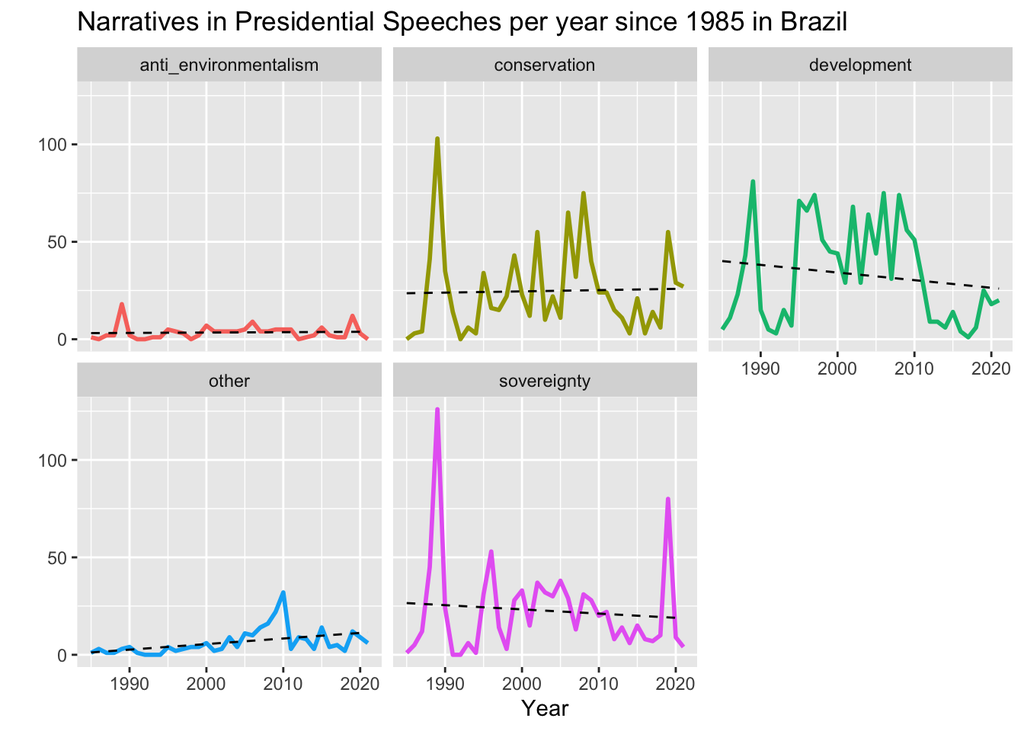

Narratives per President in Brazil (normalized)

| president | sovereignty | development | conservation | anti_environmentalism | other |
| --- | --- | --- | --- | --- | --- |
| Bolsonaro | 0.21 | 0.14 | 0.25 | 0.03 | 0.06 |
| Collor | 0.15 | 0.13 | 0.31 | 0.01 | 0.03 |
| Dilma | 0.07 | 0.07 | 0.08 | 0.02 | 0.04 |
| FHC | 0.15 | 0.31 | 0.15 | 0.02 | 0.02 |
| Itamar | 0.12 | 0.45 | 0.16 | 0.04 | 0.00 |
| Lula | 0.11 | 0.21 | 0.14 | 0.02 | 0.06 |
| Sarney | 0.33 | 0.28 | 0.26 | 0.04 | 0.02 |
| Temer | 0.06 | 0.02 | 0.05 | 0.01 | 0.03 |

| stage | sovereignty | development | conservation | anti_environmentalism | other |
| --- | --- | --- | --- | --- | --- |
| Amazonian_States | 1.28 | 2.62 | 1.40 | 0.18 | 0.22 |
| International | 0.77 | 1.36 | 0.78 | 0.12 | 0.20 |
| Non_Amazonian_States | 1.02 | 1.14 | 1.01 | 0.14 | 0.31 |
| Non_Identified | 0.67 | 1.12 | 1.28 | 0.20 | 0.28 |

# 5 Bibliography

Acker, Antoine (2013). “O maior incêndio do planeta”: como a Volkswagen e o regime militar brasileiro acidentalmente ajudaram a transformar a Amazônia em uma arena política global. Revista Brasileira de História, 34(68),13-33.[fecha de Consulta 5 de Noviembre de 2021]. ISSN: 0102-0188. Disponible en: https://www.redalyc.org/articulo.oa?id=26335781002

Arima, Eugenio Y., Paulo Barreto, Elis Araújo, and Britaldo Soares-Filho. 2014. “Public Policies Can Reduce Tropical Deforestation: Lessons and Challenges from Brazil.” Land Use Policy 41 (November): 465–73. https://doi.org/10.1016/j.landusepol.2014.06.026.

Assunção, Juliano, Clarissa Gandour, and Rudi Rocha. 2015. “Deforestation Slowdown in the Brazilian Amazon: Prices or Policies?” Environment and Development Economics 20 (6): 697–722. https://doi.org/10.1017/S1355770X15000078.

Barros, A. T. (2020). Discursos parlamentares sobre a amazônia: Sobre o que falam os deputados brasileiros. Política & Sociedade, 19(46), 299-331. doi:http://dx.doi.org/10.5007/2175-7984.2020.e66962

Boucher, Doug, Sarah Roquemore, and Estrellita Fitzhugh. 2013. “Brazil’s Success in Reducing Deforestation.” Tropical Conservation Science 6 (3): 426–45. https://doi.org/10.1177/194008291300600308.

Brice, Jessica, and Michael Smith. 2021. “The Amazon Is Fast Approaching a Point of No Return.” Bloomberg.Com, July 29, 2021. https://www.bloomberg.com/news/features/2021-07-29/amazon-rainforest-deforestation-land-grabs-surge-under-bolsonaro-in-brazil.

Drummond, J., & Barros-Platiau, A. F. (2006). Brazilian Environmental Laws and Policies, 1934– 2002: A Critical Overview. Law & Policy, 28(1), 83–108. https://doi.org/10.1111/j.1467- 9930.2005.00218.x

Harris, Bryan. 2021. “Drought Puts Amazon at Risk of ‘Large-Scale Dieback’, Researchers Warn.” Financial Times, July 19, 2021. https://www.ft.com/content/02071ae7-dcf5-4c61-9c3c-b55f5aef8b0e.

Hecht, Susanna, and Raoni Rajão. 2020. “From ‘Green Hell’ to ‘Amazonia Legal’: Land Use Models and the Re-Imagination of the Rainforest as a New Development Frontier.” Land Use Policy 96 (July): 103871. https://doi.org/10.1016/j.landusepol.2019.02.030.

Hochstetler, Kathryn, and Eduardo Viola. 2012. “Brazil and the Politics of Climate Change: Beyond the Global Commons.” Environmental Politics 21 (5): 753–71. https://doi.org/10.1080/09644016.2012.698884.

Franchini, M. A., Viola, E., Franchini, M. A., & Viola, E. (2019). Myths and images in global climate governance, conceptualization and the case of Brazil (1989—2019). Revista Brasileira de Política Internacional, 62(2). https://doi.org/10.1590/0034 7329201900205

Garfield, S. (2013). In Search of the Amazon: Brazil, the United States, and the Nature of a Region.

Lahsen, Myanna. (2009). “A Science–Policy Interface in the Global South: The Politics of Carbon Sinks and Science in Brazil.” Climatic Change 97 (3–4): 339–72. https://doi.org/10.1007/s10584-009-9610-6.

de Waroux, Y., Garrett, R. D., Chapman, M., Friis, C., Hoelle, J., Hodel, L., Hopping, K., & Zaehringer, J. G. (2021). The role of culture in land system science. Journal of Land Use Science, 0(0), 1–17. https://doi.org/10.1080/1747423X.2021.1950229

Miranda, David. 2021. “Bolsonaro’s 1,000km Amazon Railway Will Cause Climate Chaos. It Must Be Stopped | David Miranda.” The Guardian, June 2021. http://www.theguardian.com/commentisfree/2021/jul/28/bolsonaro-amazon-railway-climate-chaos-must-be-stopped.

Nepstad, Daniel, Britaldo S. Soares-Filho, Frank Merry, André Lima, Paulo Moutinho, John Carter, Maria Bowman, et al. 2009. “The End of Deforestation in the Brazilian Amazon.” Science 326 (5958): 1350–51. https://doi.org/10.1126/science.1182108./

Silva-Muller, L., & Faul, M. (2021) “Protecting the Amazon and its people: the role of civil society in the local effectiveness of transnational partnerships”. In Partnerships for Sustainability: Pathways to Effectiveness. Edt. by Andonova, L., Faul, M. and Piselli, D. Routledge: London.

Silva-Muller, L. (forthcoming) “Payment for ecosystem services and the practices of environmental fieldworkers in policy-implementation: the case of Bolsa Floresta in the Brazilian Amazon”

[^1]: Phd Candidate, The Graduate Institute Geneva, henrique.sposito@graduateinstitute.ch
[^2]: Phd Candidate, The Graduate Institute Geneva, livio.silva@graduateinstitute.ch
[^3]: Taken from here: https://www.reuters.com/article/brasil-politica-lula-amazonia-pol-idBRN2634078320080526
[^4]: Taken from here: https://g1.globo.com/politica/noticia/2018/11/28/bolsonaro-diz-que-pediu-cancelamento-da-conferencia-do-clima-no-brasil-em-2019.ghtml
[^5]: We utilize discourse and speech interchangeably, to denote general spoken communication by presidents. Narratives, on the other hand, constitute discourse.